# Bike Sharing Rentals Modelling

Data Source: https://archive.ics.uci.edu/ml/datasets/Bike+Sharing+Dataset

- Loading required libraries

```r
library(dplyr)
library(ggplot2)
library(reshape2)
library(base)
library(h2o)
```

- Preparing a class that identifies the way that date is used in the dataset

```r
setClass('myDate')
setAs('character', 'myDate', function(from) as.Date(from, format = '%Y-%m-%d'))
```

- Three dataframes can be generated based on casual, registered, and total number of rentees
  - I dropped ‘id’ because R generates its own id system for the observations
  - I also dropped ‘temperature_50’ because it is an unneeded duplicate for ‘temperature_41’

```r
casual <- read.csv('D:\\hour.csv', colClasses = c('date' = 'myDate'),
                   col.names = c('id', 'date', 'season', 'yr_2012', 'month', 'hour',
                                 'holiday', 'day_week', 'workday', 'weather',
                                 'temperature_41', 'temperature_50', 'humidity_100', 'windspeed_67',
                                 'nr_casual', 'nr_registered', 'nr_total'))[,c(2:11,13:15)]
registered <- read.csv('D:\\hour.csv', colClasses = c('date' = 'myDate'),
                       col.names = c('id', 'date', 'season', 'yr_2012', 'month', 'hour',
                                     'holiday', 'day_week', 'workday', 'weather',
                                     'temperature_41', 'temperature_50', 'humidity_100', 'windspeed_67',
                                     'nr_casual', 'nr_registered', 'nr_total'))[,c(2:11,13,14,16)]
total <- read.csv('D:\\hour.csv', colClasses = c('date' = 'myDate'),
                  col.names = c('id', 'date', 'season', 'yr_2012', 'month', 'hour',
                                'holiday', 'day_week', 'workday', 'weather',
                                'temperature_41', 'temperature_50', 'humidity_100', 'windspeed_67',
                                'nr_casual', 'nr_registered', 'nr_total'))[,c(2:11,13,14,17)]
```

- Renaming the dependent variable in the datasets

```r
colnames(casual)[colnames(casual)=='nr_casual'] <- 'nr'
colnames(registered)[colnames(registered)=='nr_registered'] <- 'nr'
colnames(total)[colnames(total)=='nr_total'] <- 'nr'
```

- Using str() to list dataframes’ columns’ names with their properties

```r
str(casual)
```

```
## 'data.frame':    17379 obs. of  13 variables:
##  $ date          : Date, format: "2011-01-01" "2011-01-01" ...
##  $ season        : int  1 1 1 1 1 1 1 1 1 1 ...
##  $ yr_2012       : int  0 0 0 0 0 0 0 0 0 0 ...
##  $ month         : int  1 1 1 1 1 1 1 1 1 1 ...
##  $ hour          : int  0 1 2 3 4 5 6 7 8 9 ...
##  $ holiday       : int  0 0 0 0 0 0 0 0 0 0 ...
##  $ day_week      : int  6 6 6 6 6 6 6 6 6 6 ...
##  $ workday       : int  0 0 0 0 0 0 0 0 0 0 ...
##  $ weather       : int  1 1 1 1 1 2 1 1 1 1 ...
##  $ temperature_41: num  0.24 0.22 0.22 0.24 0.24 0.24 0.22 0.2 0.24 0.32 ...
##  $ humidity_100  : num  0.81 0.8 0.8 0.75 0.75 0.75 0.8 0.86 0.75 0.76 ...
##  $ windspeed_67  : num  0 0 0 0 0 0.0896 0 0 0 0 ...
##  $ nr            : int  3 8 5 3 0 0 2 1 1 8 ...
```

```r
str(registered)
```

```
## 'data.frame':    17379 obs. of  13 variables:
##  $ date          : Date, format: "2011-01-01" "2011-01-01" ...
##  $ season        : int  1 1 1 1 1 1 1 1 1 1 ...
##  $ yr_2012       : int  0 0 0 0 0 0 0 0 0 0 ...
##  $ month         : int  1 1 1 1 1 1 1 1 1 1 ...
##  $ hour          : int  0 1 2 3 4 5 6 7 8 9 ...
##  $ holiday       : int  0 0 0 0 0 0 0 0 0 0 ...
##  $ day_week      : int  6 6 6 6 6 6 6 6 6 6 ...
##  $ workday       : int  0 0 0 0 0 0 0 0 0 0 ...
##  $ weather       : int  1 1 1 1 1 2 1 1 1 1 ...
##  $ temperature_41: num  0.24 0.22 0.22 0.24 0.24 0.24 0.22 0.2 0.24 0.32 ...
##  $ humidity_100  : num  0.81 0.8 0.8 0.75 0.75 0.75 0.8 0.86 0.75 0.76 ...
##  $ windspeed_67  : num  0 0 0 0 0 0.0896 0 0 0 0 ...
##  $ nr            : int  13 32 27 10 1 1 0 2 7 6 ...
```

```r
str(total)
```

```
## 'data.frame':    17379 obs. of  13 variables:
##  $ date          : Date, format: "2011-01-01" "2011-01-01" ...
##  $ season        : int  1 1 1 1 1 1 1 1 1 1 ...
##  $ yr_2012       : int  0 0 0 0 0 0 0 0 0 0 ...
##  $ month         : int  1 1 1 1 1 1 1 1 1 1 ...
##  $ hour          : int  0 1 2 3 4 5 6 7 8 9 ...
##  $ holiday       : int  0 0 0 0 0 0 0 0 0 0 ...
##  $ day_week      : int  6 6 6 6 6 6 6 6 6 6 ...
##  $ workday       : int  0 0 0 0 0 0 0 0 0 0 ...
##  $ weather       : int  1 1 1 1 1 2 1 1 1 1 ...
##  $ temperature_41: num  0.24 0.22 0.22 0.24 0.24 0.24 0.22 0.2 0.24 0.32 ...
##  $ humidity_100  : num  0.81 0.8 0.8 0.75 0.75 0.75 0.8 0.86 0.75 0.76 ...
##  $ windspeed_67  : num  0 0 0 0 0 0.0896 0 0 0 0 ...
##  $ nr            : int  16 40 32 13 1 1 2 3 8 14 ...
```

- Plotting different variables to identify unnecessary variables’ ranges
  - ‘date’, ‘yr_2012’, ‘month’, and ‘hour’ variables were not plotted because no changes shall be applied upon them anyways
  - ‘nr’ were not plotted because it is the dependent variable and no changes shall be applied upon it also

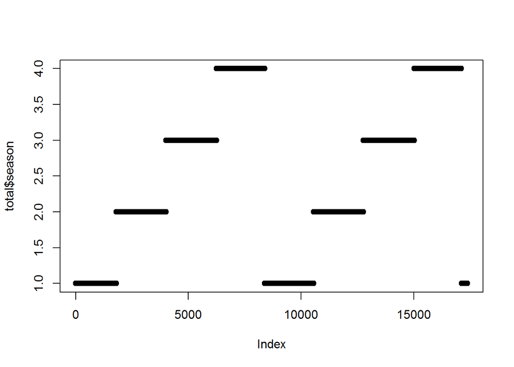

```r
plot(total$season)
```

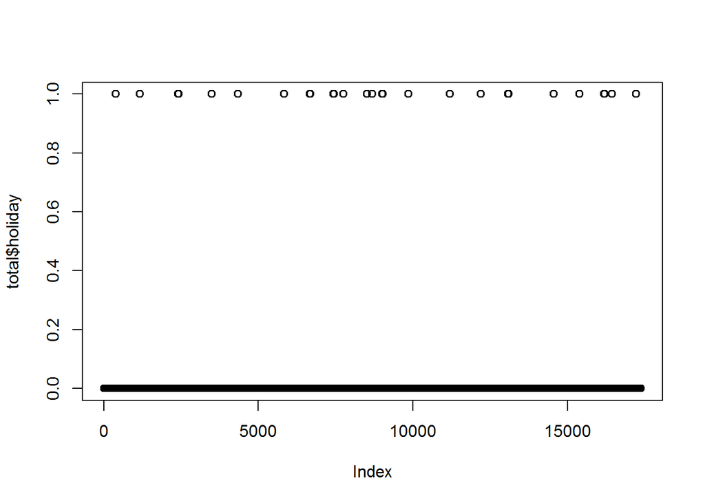

```r
plot(total$holiday)
```

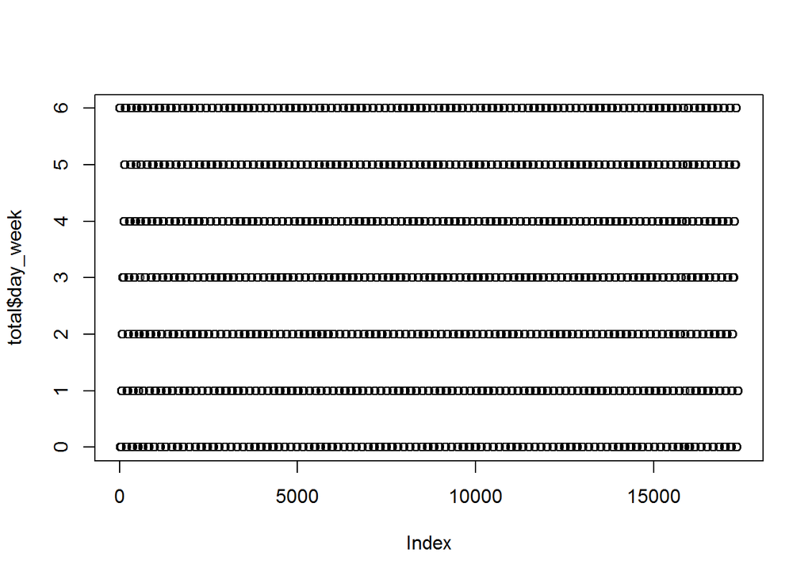

```r
plot(total$day_week)
```

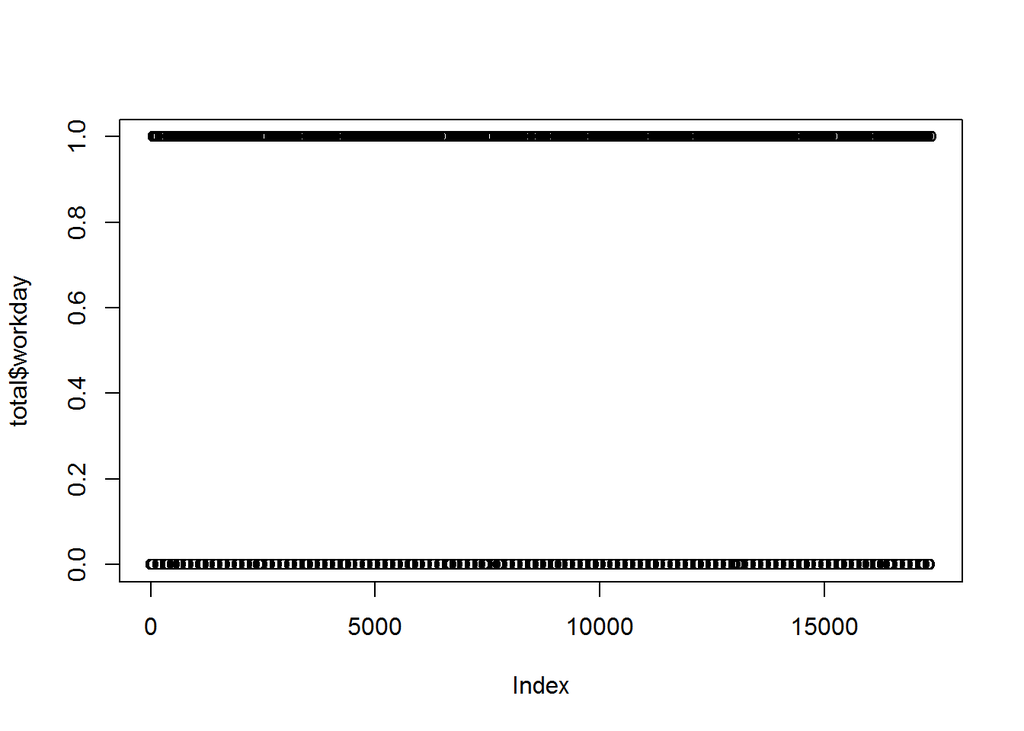

```r
plot(total$workday)
```

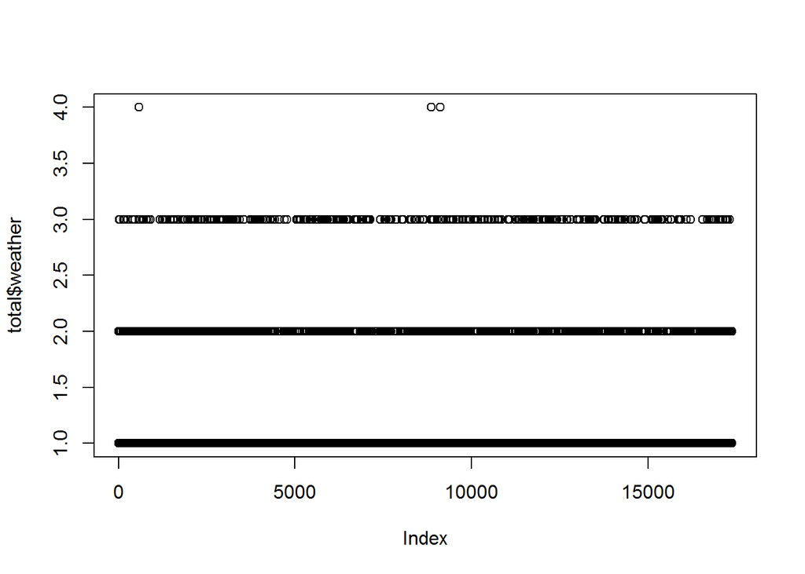

```r
plot(total$weather)
```

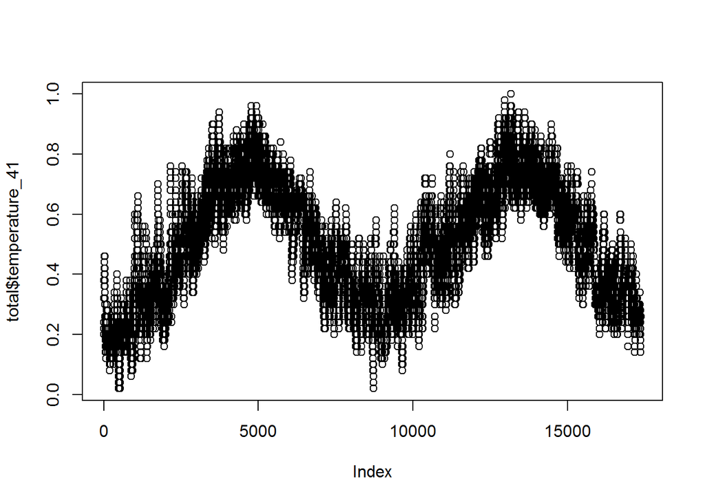

```r
plot(total$temperature_41)
```

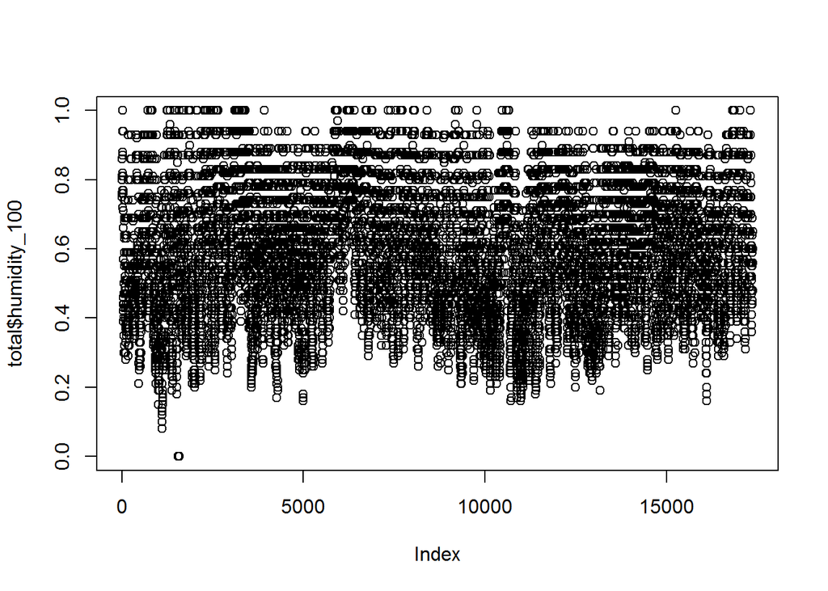

```r
plot(total$humidity_100)
```

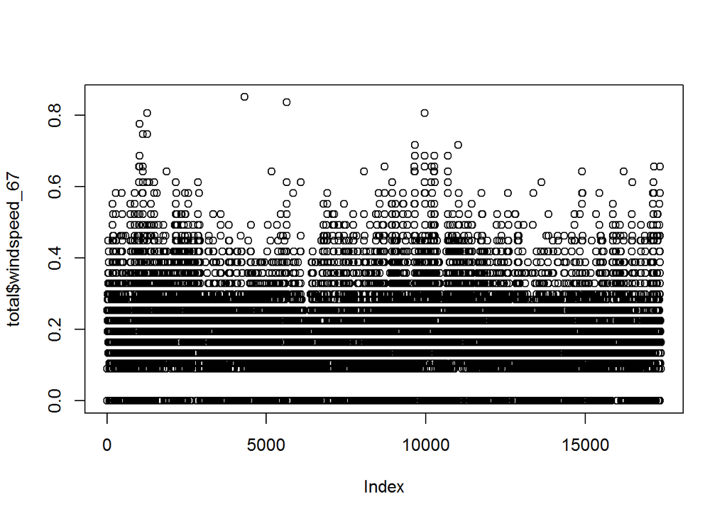

```r
plot(total$windspeed_67)
```

- After plotting, the following was decided:
  - weather = 4 is not needed because observations are too low
  - temperature_41 < 0.2 and temperature_41 > 0.8 observations can be discarded
  - humidity_100 < 0.3 and humidity_100 > 0.9 observations can also be discarded
  - windspeed_67 > 0.4 observations can also be discarded
  - ‘holiday’ variable is not needed at all because majority of values are 0’s

```r
train <- total
train <- subset(train, weather < 4)
train <- subset(train, temperature_41 > 0.2 & temperature_41 < 0.8)
train <- subset(train, humidity_100 > 0.3 & humidity_100 < 0.9)
train <- subset(train, windspeed_67 > 0.0 & windspeed_67 < 0.4)
train$holiday <- NULL
casual$holiday <- NULL
registered$holiday <- NULL
total$holiday <- NULL
```

- Using str() again to list dataframes’ columns’ names with their properties

```r
str(casual)
```

```
## 'data.frame':    17379 obs. of  12 variables:
##  $ date          : Date, format: "2011-01-01" "2011-01-01" ...
##  $ season        : int  1 1 1 1 1 1 1 1 1 1 ...
##  $ yr_2012       : int  0 0 0 0 0 0 0 0 0 0 ...
##  $ month         : int  1 1 1 1 1 1 1 1 1 1 ...
##  $ hour          : int  0 1 2 3 4 5 6 7 8 9 ...
##  $ day_week      : int  6 6 6 6 6 6 6 6 6 6 ...
##  $ workday       : int  0 0 0 0 0 0 0 0 0 0 ...
##  $ weather       : int  1 1 1 1 1 2 1 1 1 1 ...
##  $ temperature_41: num  0.24 0.22 0.22 0.24 0.24 0.24 0.22 0.2 0.24 0.32 ...
##  $ humidity_100  : num  0.81 0.8 0.8 0.75 0.75 0.75 0.8 0.86 0.75 0.76 ...
##  $ windspeed_67  : num  0 0 0 0 0 0.0896 0 0 0 0 ...
##  $ nr            : int  3 8 5 3 0 0 2 1 1 8 ...
```

```r
str(registered)
```

```
## 'data.frame':    17379 obs. of  12 variables:
##  $ date          : Date, format: "2011-01-01" "2011-01-01" ...
##  $ season        : int  1 1 1 1 1 1 1 1 1 1 ...
##  $ yr_2012       : int  0 0 0 0 0 0 0 0 0 0 ...
##  $ month         : int  1 1 1 1 1 1 1 1 1 1 ...
##  $ hour          : int  0 1 2 3 4 5 6 7 8 9 ...
##  $ day_week      : int  6 6 6 6 6 6 6 6 6 6 ...
##  $ workday       : int  0 0 0 0 0 0 0 0 0 0 ...
##  $ weather       : int  1 1 1 1 1 2 1 1 1 1 ...
##  $ temperature_41: num  0.24 0.22 0.22 0.24 0.24 0.24 0.22 0.2 0.24 0.32 ...
##  $ humidity_100  : num  0.81 0.8 0.8 0.75 0.75 0.75 0.8 0.86 0.75 0.76 ...
##  $ windspeed_67  : num  0 0 0 0 0 0.0896 0 0 0 0 ...
##  $ nr            : int  13 32 27 10 1 1 0 2 7 6 ...
```

```r
str(total)
```

```
## 'data.frame':    17379 obs. of  12 variables:
##  $ date          : Date, format: "2011-01-01" "2011-01-01" ...
##  $ season        : int  1 1 1 1 1 1 1 1 1 1 ...
##  $ yr_2012       : int  0 0 0 0 0 0 0 0 0 0 ...
##  $ month         : int  1 1 1 1 1 1 1 1 1 1 ...
##  $ hour          : int  0 1 2 3 4 5 6 7 8 9 ...
##  $ day_week      : int  6 6 6 6 6 6 6 6 6 6 ...
##  $ workday       : int  0 0 0 0 0 0 0 0 0 0 ...
##  $ weather       : int  1 1 1 1 1 2 1 1 1 1 ...
##  $ temperature_41: num  0.24 0.22 0.22 0.24 0.24 0.24 0.22 0.2 0.24 0.32 ...
##  $ humidity_100  : num  0.81 0.8 0.8 0.75 0.75 0.75 0.8 0.86 0.75 0.76 ...
##  $ windspeed_67  : num  0 0 0 0 0 0.0896 0 0 0 0 ...
##  $ nr            : int  16 40 32 13 1 1 2 3 8 14 ...
```

```r
str(train)
```

```
## 'data.frame':    11200 obs. of  12 variables:
##  $ date          : Date, format: "2011-01-01" "2011-01-01" ...
##  $ season        : int  1 1 1 1 1 1 1 1 1 1 ...
##  $ yr_2012       : int  0 0 0 0 0 0 0 0 0 0 ...
##  $ month         : int  1 1 1 1 1 1 1 1 1 1 ...
##  $ hour          : int  5 10 11 12 13 14 15 16 17 18 ...
##  $ day_week      : int  6 6 6 6 6 6 6 6 6 6 ...
##  $ workday       : int  0 0 0 0 0 0 0 0 0 0 ...
##  $ weather       : int  2 1 1 1 2 2 2 2 2 3 ...
##  $ temperature_41: num  0.24 0.38 0.36 0.42 0.46 0.46 0.44 0.42 0.44 0.42 ...
##  $ humidity_100  : num  0.75 0.76 0.81 0.77 0.72 0.72 0.77 0.82 0.82 0.88 ...
##  $ windspeed_67  : num  0.0896 0.2537 0.2836 0.2836 0.2985 ...
##  $ nr            : int  1 36 56 84 94 106 110 93 67 35 ...
```

- Printing a summary of basic characteristics of ‘train’ dataframe
- Checking if there is any NA or less-than-a-zero value

```r
summary(train)
```

```
##       date                season         yr_2012           month
##  Min.   :2011-01-01   Min.   :1.000   Min.   :0.0000   Min.   : 1.000
##  1st Qu.:2011-07-28   1st Qu.:2.000   1st Qu.:0.0000   1st Qu.: 4.000
##  Median :2012-01-31   Median :3.000   Median :1.0000   Median : 7.000
##  Mean   :2012-01-22   Mean   :2.592   Mean   :0.5302   Mean   : 6.856
##  3rd Qu.:2012-07-21   3rd Qu.:4.000   3rd Qu.:1.0000   3rd Qu.:10.000
##  Max.   :2012-12-31   Max.   :4.000   Max.   :1.0000   Max.   :12.000
##       hour          day_week       workday          weather
##  Min.   : 0.00   Min.   :0.00   Min.   :0.0000   Min.   :1.0
##  1st Qu.: 6.00   1st Qu.:1.00   1st Qu.:0.0000   1st Qu.:1.0
##  Median :11.00   Median :3.00   Median :1.0000   Median :1.0
##  Mean   :11.62   Mean   :3.01   Mean   :0.6767   Mean   :1.4
##  3rd Qu.:18.00   3rd Qu.:5.00   3rd Qu.:1.0000   3rd Qu.:2.0
##  Max.   :23.00   Max.   :6.00   Max.   :1.0000   Max.   :3.0
##  temperature_41    humidity_100     windspeed_67          nr
##  Min.   :0.2200   Min.   :0.3100   Min.   :0.0896   Min.   :  1.0
##  1st Qu.:0.3600   1st Qu.:0.5100   1st Qu.:0.1343   1st Qu.: 48.0
##  Median :0.5200   Median :0.6500   Median :0.1940   Median :153.0
##  Mean   :0.5053   Mean   :0.6343   Mean   :0.1983   Mean   :197.6
##  3rd Qu.:0.6400   3rd Qu.:0.7700   3rd Qu.:0.2537   3rd Qu.:289.0
##  Max.   :0.7800   Max.   :0.8900   Max.   :0.3881   Max.   :977.0
```

```r
sapply(train, function(x) sum(is.na(x)))
```

```
##           date         season        yr_2012          month           hour
##              0              0              0              0              0
##       day_week        workday        weather temperature_41   humidity_100
##              0              0              0              0              0
##   windspeed_67             nr
##              0              0
```

```r
sapply(train, function(x) sum(x<0, na.rm=TRUE))
```

```
##           date         season        yr_2012          month           hour
##              0              0              0              0              0
##       day_week        workday        weather temperature_41   humidity_100
##              0              0              0              0              0
##   windspeed_67             nr
##              0              0
```

- Plotting all variables based on ‘yr_2012’ to identify observations that happened in 2011 and those that happened in 2012
  - If I want to use a logarithmic scale I would need to deal with 0’s

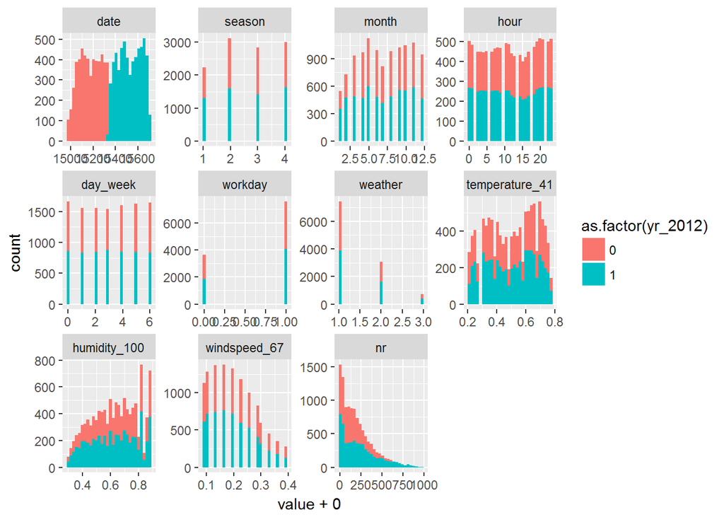

```r
train %>% melt(id.vars = "yr_2012") %>% tbl_df %>%
  ggplot() + geom_histogram(aes(x = value+0.000, fill = as.factor(yr_2012))) +
  facet_wrap(~ variable, scales = "free") #+ scale_x_log10()
```

- Plotting count of ‘nr’ across ‘nr’ based on:
  - ‘season’ variable
  - ‘yr_2012’ variable
  - ‘month’ variable
  - ‘hour’ variable
  - ‘day_week’ variable
  - ‘work_day’ variable
  - ‘weather’ variable
- If I want to use a logarithmic scale I would need to deal with 0’s

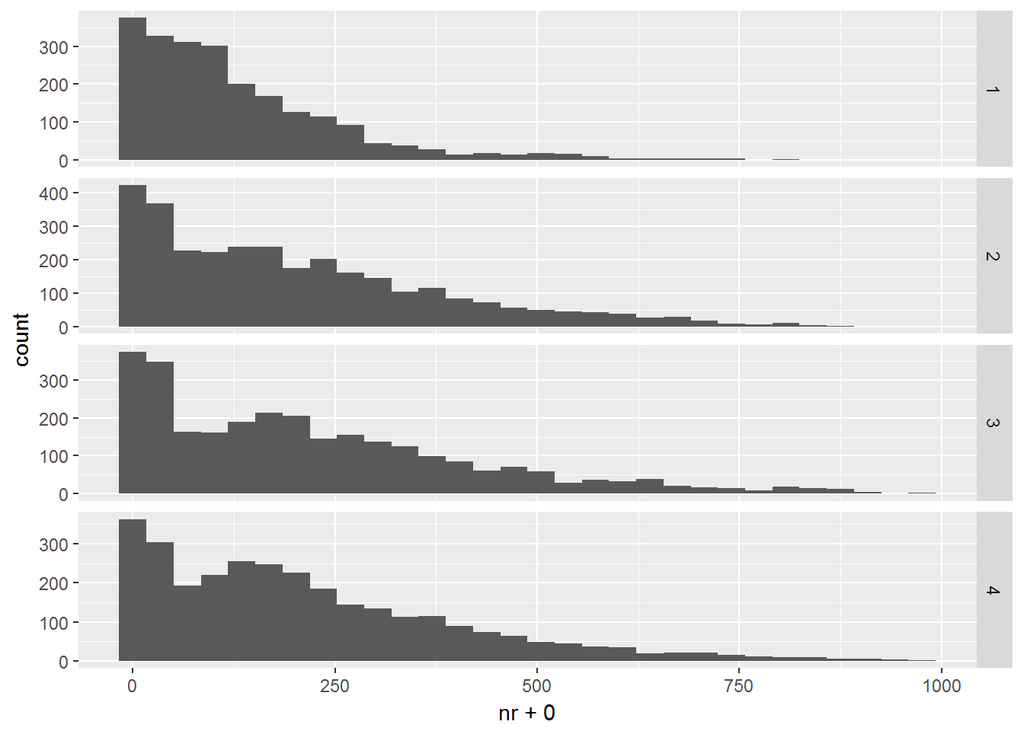

```r
ggplot(train) + geom_histogram(aes(x = nr+0.000)) +
  facet_grid(season~., scales = "free") #+ scale_x_log10()
```

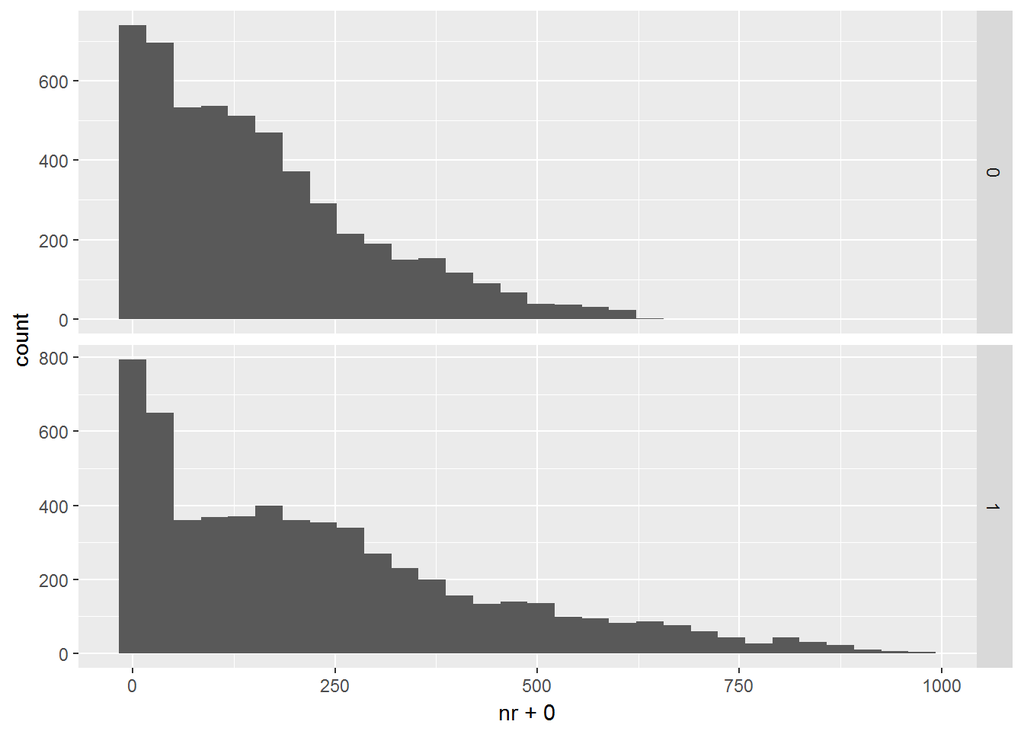

```r
ggplot(train) + geom_histogram(aes(x = nr+0.000)) +
  facet_grid(yr_2012~., scales = "free") #+ scale_x_log10()
```

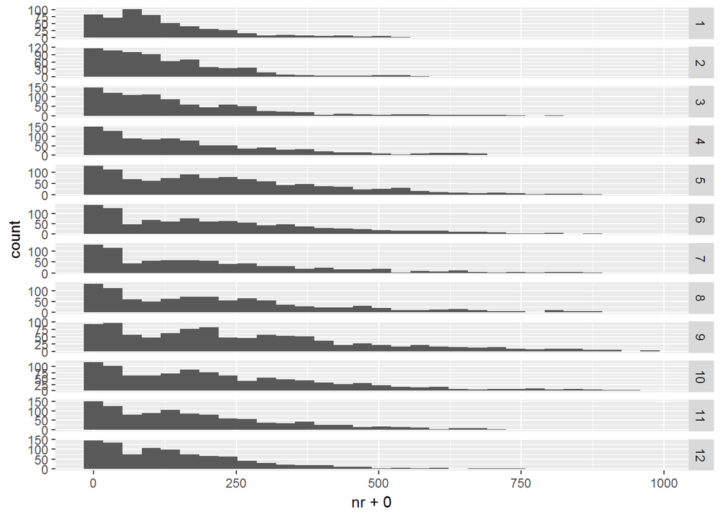

```r
ggplot(train) + geom_histogram(aes(x = nr+0.000)) +
  facet_grid(month~., scales = "free") #+ scale_x_log10()
```

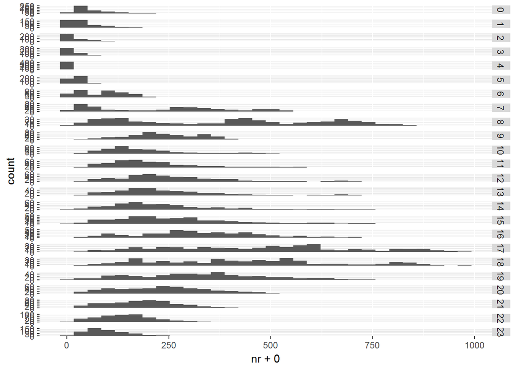

```r
ggplot(train) + geom_histogram(aes(x = nr+0.000)) +
  facet_grid(hour~., scales = "free") #+ scale_x_log10()
```

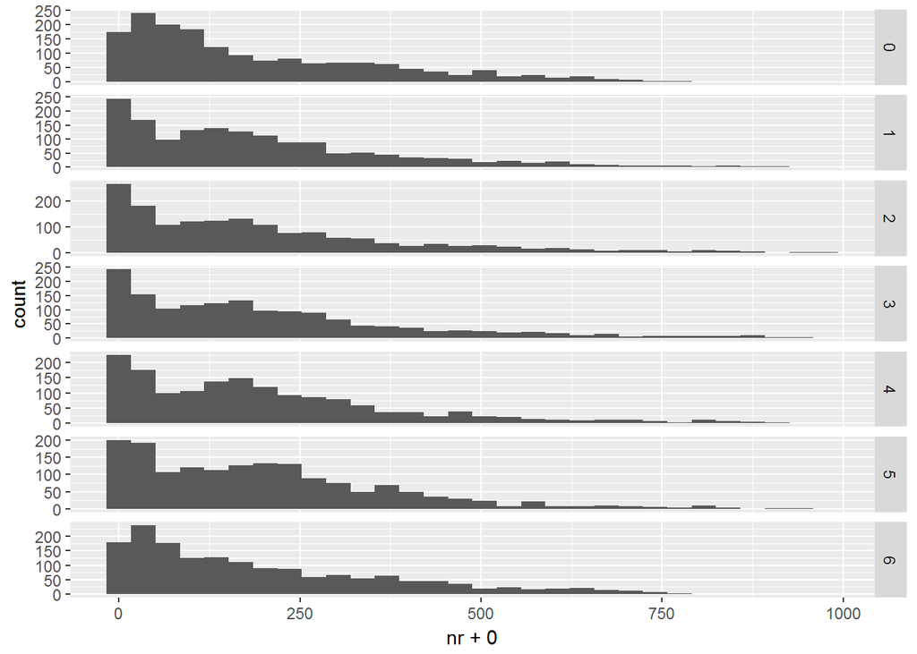

```r
ggplot(train) + geom_histogram(aes(x = nr+0.000)) +
  facet_grid(day_week~., scales = "free") #+ scale_x_log10()
```

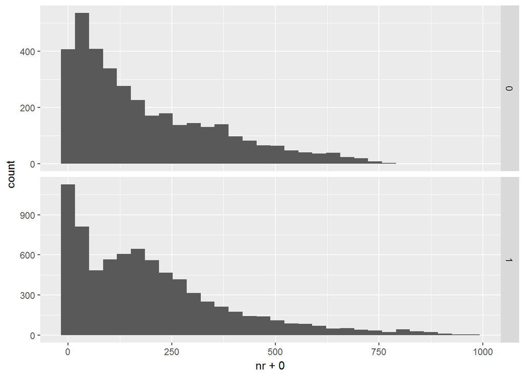

```r
ggplot(train) + geom_histogram(aes(x = nr+0.000)) +
  facet_grid(workday~., scales = "free") #+ scale_x_log10()
```

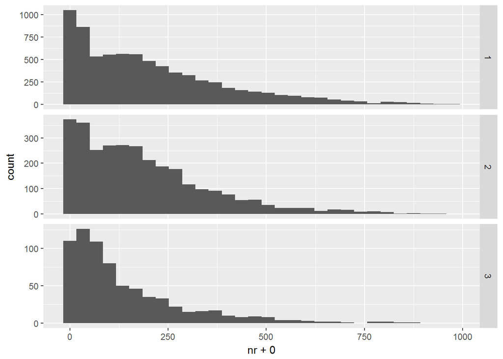

```r
ggplot(train) + geom_histogram(aes(x = nr+0.000)) +
  facet_grid(weather~., scales = "free") #+ scale_x_log10()
```

- Displaying lists of the following properties:
  1. Number and percentage of observations for each available value of ‘day_week’ and ‘workday’
  2. Number and percentage of observations for each available value of ‘month’ and ‘hour’ when ‘nr’ was greater than 250
  3. Number and percentage of observations for each available value of ‘workday’ when ‘nr’ was greater than 400
  4. Maximum number of rentals in each available value of ‘season’
  5. each ‘month’ and ‘nr’ value when ‘windspeed_67’ was greater than 0.3 and ‘humidity_100’ was smaller than 0.5

```r
train %>% group_by(day_week, workday) %>% summarize(n = n()) %>%
  mutate(pc = n/sum(n)*100)
```

```
## Source: local data frame [12 x 4]
## Groups: day_week [7]
##
##    day_week workday     n          pc
##       <int>   <int> <int>       <dbl>
## 1         0       0  1664 100.0000000
## 2         1       0   225  14.4046095
## 3         1       1  1337  85.5953905
## 4         2       0    16   1.0256410
## 5         2       1  1544  98.9743590
## 6         3       0     6   0.3896104
## 7         3       1  1534  99.6103896
## 8         4       0    33   2.0560748
## 9         4       1  1572  97.9439252
## 10        5       0    35   2.1511985
## 11        5       1  1592  97.8488015
## 12        6       0  1642 100.0000000
```

```r
train %>% filter(nr>250) %>%
  group_by(month, hour) %>% summarize(n = n()) %>%
  mutate(pc = n/sum(n)*100) %>% as.data.frame()
```

```
##     month hour  n         pc
## 1       1    7  3  4.6875000
## 2       1    8  8 12.5000000
## 3       1    9  3  4.6875000
## 4       1   11  3  4.6875000
## 5       1   12  3  4.6875000
## 6       1   13  3  4.6875000
## 7       1   14  4  6.2500000
## 8       1   15  4  6.2500000
## 9       1   16  5  7.8125000
## 10      1   17 10 15.6250000
## 11      1   18  9 14.0625000
## 12      1   19  9 14.0625000
## 13      2    7 10  9.7087379
## 14      2    8 12 11.6504854
```

[output cut: 170 more lines]

```r
train %>% filter(nr>400) %>%
  group_by(workday) %>% summarize(n = n()) %>%
  mutate(pc = n/sum(n)*100)
```

```
## # A tibble: 2 × 3
##   workday     n       pc
##     <int> <int>    <dbl>
## 1       0   495 32.01811
## 2       1  1051 67.98189
```

```r
train %>% group_by(season) %>%
  summarize(max = max(nr))
```

```
## # A tibble: 4 × 2
##   season   max
##    <int> <int>
## 1      1   801
## 2      2   957
## 3      3   977
## 4      4   967
```

```r
train %>% filter(windspeed_67>0.3 & humidity_100<0.5) %>%
  select(month, nr)
```

```
##     month  nr
## 1       1  53
## 2       1  22
## 3       1  31
## 4       1   5
## 5       1 115
## 6       1  57
## 7       1  46
## 8       1  79
## 9       1  63
## 10      1  82
## 11      1  49
## 12      1  68
## 13      1  42
## 14      1  78
```

[output cut: 439 more lines]

- I wanted to use the following code to divide the training set randomly into 5 datasets to ensure cross-validation but an easier way to do it in H2O Package made me comment the following lines

```r
#idx_1 <- sample(1:nrow(train), nrow(train)*0.2)
#idx_2 <- sample(setdiff(1:nrow(train), idx_1), nrow(train)*0.2)
#idx_3 <- sample(setdiff(1:nrow(train), c(idx_1,idx_2)), nrow(train)*0.2)
#idx_4 <- sample(setdiff(1:nrow(train), c(idx_1,idx_2,idx_3)), nrow(train)*0.2)
#idx_5 <- sample(setdiff(1:nrow(train), c(idx_1,idx_2,idx_3,idx_4)), nrow(train)*0.2)

#t1 <- train[idx_1,]
#t2 <- train[idx_2,]
#t3 <- train[idx_3,]
#t4 <- train[idx_4,]
#t5 <- train[idx_5,]
#rm(idx_1,idx_2,idx_3,idx_4,idx_5)
```

- The first line disables the progress bar of H2O functions
- The second line initializes a connction between the H2O online app and R with 8 GB of memory and freedom of using any available CPU

```r
h2o.no_progress()
h2o.init(max_mem_size = '8g', nthreads = -1)
```

```
##
## H2O is not running yet, starting it now...
##
## Note:  In case of errors look at the following log files:
##     C:\Users\ADMINI~1\AppData\Local\Temp\Rtmp8qSZYV/h2o_Administrator_started_from_r.out
##     C:\Users\ADMINI~1\AppData\Local\Temp\Rtmp8qSZYV/h2o_Administrator_started_from_r.err
##
##
## Starting H2O JVM and connecting: . Connection successful!
##
## R is connected to the H2O cluster:
##     H2O cluster uptime:         2 seconds 94 milliseconds
##     H2O cluster version:        3.10.3.6
##     H2O cluster version age:    1 month and 6 days
##     H2O cluster name:           H2O_started_from_R_Administrator_agd541
##     H2O cluster total nodes:    1
##     H2O cluster total memory:   7.11 GB
##     H2O cluster total cores:    4
##     H2O cluster allowed cores:  4
##     H2O cluster healthy:        TRUE
##     H2O Connection ip:          localhost
##     H2O Connection port:        54321
##     H2O Connection proxy:       NA
##     R Version:                  R version 3.3.3 (2017-03-06)
```

- The following line results in a random split of the training set into two sets of 60% and 40% of the original set

```r
splits <- h2o.splitFrame(as.h2o(train), ratios = 0.6)
```

- The following grid search evaluates a random forest algorithm over many options

```r
rf_g <- h2o.grid('randomForest', x = 1:11, y = 12, nfolds = 3,
                 training_frame = splits[[1]], validation_frame = splits[[2]],
                 hyper_params = list(ntrees = c(10, 50, 100),
                                     max_depth = c(10, 20, 50),
                                     nbins = c(10, 20, 50)))
```

- The following grid search evaluates a generalized boosted model algorithm over many options

```r
gbm_g <- h2o.grid('gbm', x = 1:11, y = 12, nfolds = 3,
                  training_frame = splits[[1]], validation_frame = splits[[2]],
                  hyper_params = list(ntrees = c(10, 50, 100),
                                      max_depth = c(10, 20, 50),
                                      nbins = c(10, 20, 50),
                                      learn_rate = c(0.02, 0.2)))
```

- The following grid search evaluates a deep learning algorithm over many options

```r
dl_g <- h2o.grid('deeplearning', x = 1:11, y = 12, nfolds = 3,
                 training_frame = splits[[1]], validation_frame = splits[[2]],
                 hyper_params = list(activation = c('Tanh',
                                                    'TanhWithDropout',
                                                    'Rectifier',
                                                    'RectifierWithDropout',
                                                    'Maxout',
                                                    'MaxoutWithDropout')))
```

- The following grid search evaluates a generalized linear model algorithm over many options
- I had to process additional 4 separate GLM algorithms because ‘family’ option in the GLM algorithm is not gridable

```r
glm_g <- h2o.grid('glm', x = 1:11, y = 12, nfolds = 3,
                  training_frame = splits[[1]], validation_frame = splits[[2]],
                  hyper_params = list(alpha = c(0.1, 0.5, 1)))
glm_1 <- h2o.glm(x = 1:11, y = 12, nfolds = 3,
                 training_frame = splits[[1]],
                 validation_frame = splits[[2]])
glm_2 <- h2o.glm(x = 1:11, y = 12, nfolds = 3,
                 training_frame = splits[[1]],
                 validation_frame = splits[[2]],
                 family = 'poisson')
glm_3 <- h2o.glm(x = 1:11, y = 12, nfolds = 3,
                 training_frame = splits[[1]],
                 validation_frame = splits[[2]],
                 family = 'gamma')
glm_4 <- h2o.glm(x = 1:11, y = 12, nfolds = 3,
                 training_frame = splits[[1]],
                 validation_frame = splits[[2]],
                 family = 'tweedie')
```

- The first four lines return the least residual deviance in each grid search
- The second four lines return the residual deviance in each manually-created GLM

```r
rf_g@summary_table$residual_deviance[1]
```

```
## [1] "4832.831799574587"
```

```r
gbm_g@summary_table$residual_deviance[1]
```

```
## [1] "2005.7544582160253"
```

```r
dl_g@summary_table$residual_deviance[1]
```

```
## [1] "3333.7304443173375"
```

```r
glm_g@summary_table$residual_deviance[1]
```

```
## [1] "1.430649249332664E8"
```

```r
h2o.performance(glm_1,splits[[2]])@metrics$residual_deviance
```

```
## [1] 98588648
```

```r
h2o.performance(glm_2,splits[[2]])@metrics$residual_deviance
```

```
## [1] 472126.1
```

```r
h2o.performance(glm_3,splits[[2]])@metrics$residual_deviance
```

```
## [1] 4654.918
```

```r
h2o.performance(glm_4,splits[[2]])@metrics$residual_deviance
```

```
## [1] 98588649
```

- The following lines return the mean squared error of validating the original ‘total’ dataframe

```r
h2o.performance(h2o.getModel(rf_g@model_ids[[1]]), as.h2o(total))@metrics$MSE
```

```
## [1] 2894.466
```

```r
h2o.performance(h2o.getModel(gbm_g@model_ids[[1]]), as.h2o(total))@metrics$MSE
```

```
## [1] 1446.029
```

```r
h2o.performance(h2o.getModel(dl_g@model_ids[[1]]), as.h2o(total))@metrics$MSE
```

```
## [1] 3509.074
```

```r
h2o.performance(h2o.getModel(glm_g@model_ids[[1]]), as.h2o(total))@metrics$MSE
```

```
## [1] 20637.79
```

```r
h2o.performance(glm_1, as.h2o(total))@metrics$MSE
```

```
## [1] 20417.95
```

```r
h2o.performance(glm_2, as.h2o(total))@metrics$MSE
```

```
## [1] 22098.97
```

```r
h2o.performance(glm_3, as.h2o(total))@metrics$MSE
```

```
## [1] 3847942
```

```r
h2o.performance(glm_4, as.h2o(total))@metrics$MSE
```

```
## [1] 20417.95
```

- The following lines return the mean squared error of validating the original ‘casual’ dataframe

```r
h2o.performance(h2o.getModel(rf_g@model_ids[[1]]), as.h2o(casual))@metrics$MSE
```

```
## [1] 43758.12
```

```r
h2o.performance(h2o.getModel(gbm_g@model_ids[[1]]), as.h2o(casual))@metrics$MSE
```

```
## [1] 48141.33
```

```r
h2o.performance(h2o.getModel(dl_g@model_ids[[1]]), as.h2o(casual))@metrics$MSE
```

```
## [1] 45491.97
```

```r
h2o.performance(h2o.getModel(glm_g@model_ids[[1]]), as.h2o(casual))@metrics$MSE
```

```
## [1] 36818.08
```

```r
h2o.performance(glm_1, as.h2o(casual))@metrics$MSE
```

```
## [1] 35452.5
```

```r
h2o.performance(glm_2, as.h2o(casual))@metrics$MSE
```

```
## [1] 43425.87
```

```r
h2o.performance(glm_3, as.h2o(casual))@metrics$MSE
```

```
## [1] 3882550
```

```r
h2o.performance(glm_4, as.h2o(casual))@metrics$MSE
```

```
## [1] 35452.5
```

- The following lines return the mean squared error of validating the original ‘registered’ dataframe

```r
h2o.performance(h2o.getModel(rf_g@model_ids[[1]]), as.h2o(registered))@metrics$MSE
```

```
## [1] 6025.756
```

```r
h2o.performance(h2o.getModel(gbm_g@model_ids[[1]]), as.h2o(registered))@metrics$MSE
```

```
## [1] 5291.809
```

```r
h2o.performance(h2o.getModel(dl_g@model_ids[[1]]), as.h2o(registered))@metrics$MSE
```

```
## [1] 6222.77
```

```r
h2o.performance(h2o.getModel(glm_g@model_ids[[1]]), as.h2o(registered))@metrics$MSE
```

```
## [1] 19363.11
```

```r
h2o.performance(glm_1, as.h2o(registered))@metrics$MSE
```

```
## [1] 18737.47
```

```r
h2o.performance(glm_2, as.h2o(registered))@metrics$MSE
```

```
## [1] 22314.89
```

```r
h2o.performance(glm_3, as.h2o(registered))@metrics$MSE
```

```
## [1] 3853166
```

```r
h2o.performance(glm_4, as.h2o(registered))@metrics$MSE
```

```
## [1] 18737.47
```

- This line finishes the established connection between H2O online app and R

```r
h2o.shutdown(prompt = FALSE)
```

```
## [1] TRUE
```

### Conclusions

- Based on the above results we can conclude the following:
  - Generalized Boosted Model (GBM) was the most successful model for this dataset
  - GBM could model ‘train’, ‘total’, and ‘registered’ dataframes successfully
  - Any of the used models could not model ‘casual’ dataframe
  - Generalized Linear Model (GLM) with Gamma distribution was the most unsuccessful model to be used
  - GLM in general was not a successful model to be used with this dataset compared to RF, GBM, and DL